# Chapter - 3

*Q8. sThis question involves the use of simple linear regression on the “Auto” data set.*

1. Use the lm() function to perform a simple linear regression with “mpg” as the response and “horsepower” as the predictor. Use the summary() function to print the results. Comment on the output. For example :
2. Is there a relationship between the predictor and the response ?

```r
library(ISLR)
data(Auto)
fit <- lm(mpg ~ horsepower, data = Auto)
summary(fit)
```

```
Call:
lm(formula = mpg ~ horsepower, data = Auto)

Residuals:
     Min       1Q   Median       3Q      Max
-13.5710  -3.2592  -0.3435   2.7630  16.9240

Coefficients:
             Estimate Std. Error t value Pr(>|t|)
(Intercept) 39.935861   0.717499   55.66   <2e-16 ***
horsepower  -0.157845   0.006446  -24.49   <2e-16 ***
---
Signif. codes:
0 ‘***’ 0.001 ‘**’ 0.01 ‘*’ 0.05 ‘.’ 0.1 ‘ ’ 1

Residual standard error: 4.906 on 390 degrees of freedom
Multiple R-squared:  0.6059,    Adjusted R-squared:  0.6049
F-statistic: 599.7 on 1 and 390 DF,  p-value: < 2.2e-16
```

2. How strong is the relationship between the predictor and the response ?

We use the mean of the response and the RSE to calculate the residual error relative to the response. The average mpg is 23.4459184 miles per gallon. The lm. fit RSE was 4.9057569, indicating a percentage error of 20.9237141 percent. It’s also worth noting that, with an R2 of 0.6059483, “horsepower” can explain nearly 60.5948258 percent of the variation in “mpg.”

3. Is the relationship between the predictor and the response positive or negative ?

Because the “horsepower” coeficient is negative, the relationship is also negative. The linear regression indicates that the more horsepower an automobile has, the lower the mpg fuel efficiency.

4. What is the predicted mpg associated with a “horsepower” of 98 ? What are the associated 95% confidence and prediction intervals ?

```r
predict(fit, data.frame(horsepower = 98), interval = "confidence")
```

```
       fit      lwr      upr
1 24.46708 23.97308 24.96108
```

```r
predict(fit, data.frame(horsepower = 98), interval = "prediction")
```

```
       fit     lwr      upr
1 24.46708 14.8094 34.12476
```

2. Plot the response and the predictor. Use the abline() function to display the least squares regression line.

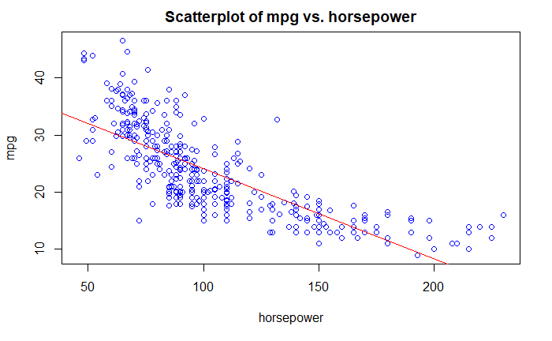

```r
plot(Auto$horsepower, Auto$mpg, main = "Scatterplot of mpg vs. horsepower", xlab = "horsepower", ylab = "mpg", col = "blue")
abline(fit, col = "red")
```

3. Use the plot() function to produce diagnostic plots of the least squares regression fit. Comment on any problems you see with the fit.

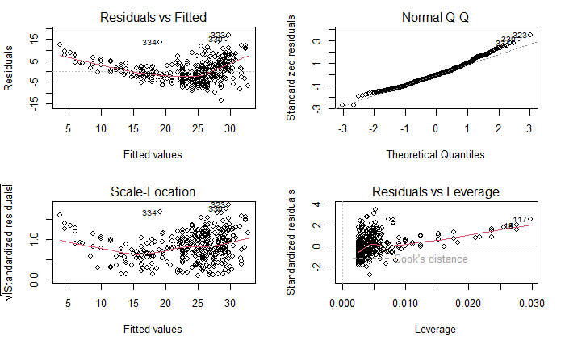

```r
par(mfrow = c(2, 2))
plot(fit)
```

The presence of non linearity in the data is indicated by the plot of residuals versus fitted values. The plot of standardized residuals vs. leverage reveals a few outliers (values greater than 2 or less than -2) as well as a few high leverage points.

*Q9. This question involves the use of multiple linear regression on the “Auto” data set.*